# Project: Train a Quadcopter How to Fly

Design an agent to fly a quadcopter, and then train it using a reinforcement learning algorithm of your choice!

Try to apply the techniques you have learnt, but also feel free to come up with innovative ideas and test them.

## Instructions

Take a look at the files in the directory to better understand the structure of the project.

- `task.py`: Define your task (environment) in this file.
- `agents/`: Folder containing reinforcement learning agents.
  - `policy_search.py`: A sample agent has been provided here.
  - `agent.py`: Develop your agent here.
- `physics_sim.py`: This file contains the simulator for the quadcopter. **DO NOT MODIFY THIS FILE**.

For this project, you will define your own task in `task.py`. Although we have provided a example task to get you started, you are encouraged to change it. Later in this notebook, you will learn more about how to amend this file.

You will also design a reinforcement learning agent in `agent.py` to complete your chosen task.

You are welcome to create any additional files to help you to organize your code. For instance, you may find it useful to define a `model.py` file defining any needed neural network architectures.

## Controlling the Quadcopter

We provide a sample agent in the code cell below to show you how to use the sim to control the quadcopter. This agent is even simpler than the sample agent that you'll examine (in `agents/policy_search.py`) later in this notebook!

The agent controls the quadcopter by setting the revolutions per second on each of its four rotors. The provided agent in the `Basic_Agent` class below always selects a random action for each of the four rotors. These four speeds are returned by the `act` method as a list of four floating-point numbers.

For this project, the agent that you will implement in `agents/agent.py` will have a far more intelligent method for selecting actions!

```python
import random

class Basic_Agent():
    def __init__(self, task):
        self.task = task

    def act(self):
        new_thrust = random.gauss(450., 25.)
        return [new_thrust + random.gauss(0., 1.) for x in range(4)]
```

Run the code cell below to have the agent select actions to control the quadcopter.

Feel free to change the provided values of `runtime`, `init_pose`, `init_velocities`, and `init_angle_velocities` below to change the starting conditions of the quadcopter.

The `labels` list below annotates statistics that are saved while running the simulation. All of this information is saved in a text file `data.txt` and stored in the dictionary `results`.

```python
%load_ext autoreload
%autoreload 2

import csv
import numpy as np
from task import Task

# Modify the values below to give the quadcopter a different starting position.
runtime = 5.                                    # time limit of the episode
init_pose = np.array([10., 10., 10., 0., 0., 0.])   # initial pose
target_pos = np.array([20., 20., 100.])
init_velocities = np.array([0., 0., 0.])         # initial velocities
init_angle_velocities = np.array([0., 0., 0.])   # initial angle velocities
num_episodes = 1000

labels = ['time',
          'x', 'y', 'z', 'phi', 'theta', 'psi',
          'x_velocity', 'y_velocity', 'z_velocity',
          'phi_velocity', 'theta_velocity', 'psi_velocity',
          'rotor_speed1', 'rotor_speed2', 'rotor_speed3', 'rotor_speed4',
          'reward']
results = {x : [] for x in labels}
```

```
The autoreload extension is already loaded. To reload it, use:
  %reload_ext autoreload
```

```python
file_output = 'data.csv'                         # file name for saved results

# Setup
task = Task(init_pose, init_velocities, init_angle_velocities, runtime, target_pos)
agent = Basic_Agent(task)
done = False

# Run the simulation, and save the results.
with open(file_output, 'w') as csvfile:
    writer = csv.writer(csvfile)
    writer.writerow(labels)
    while True:
        rotor_speeds = agent.act()
        _, reward, done = task.step(rotor_speeds)

        to_write = [task.sim.time] + \
            list(task.sim.pose) + \
            list(task.sim.v) + \
            list(task.sim.angular_v) + \
            list(rotor_speeds) + \
            [reward]

        for ii in range(len(labels)):
            results[labels[ii]].append(to_write[ii])
        writer.writerow(to_write)
        if done:
            break
```

Run the code cell below to visualize how the position of the quadcopter evolved during the simulation.

```python
import matplotlib.pyplot as plt
%matplotlib inline
```

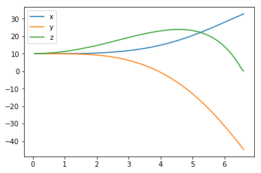

```python
plt.plot(results['time'], results['x'], label='x')
plt.plot(results['time'], results['y'], label='y')
plt.plot(results['time'], results['z'], label='z')
plt.legend()
_ = plt.ylim()
```

The next code cell visualizes the velocity of the quadcopter.

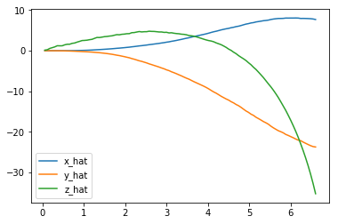

```python
plt.plot(results['time'], results['x_velocity'], label='x_hat')
plt.plot(results['time'], results['y_velocity'], label='y_hat')
plt.plot(results['time'], results['z_velocity'], label='z_hat')
plt.legend()
_ = plt.ylim()
```

Next, you can plot the Euler angles (the rotation of the quadcopter over the $x$-, $y$-, and $z$-axes),

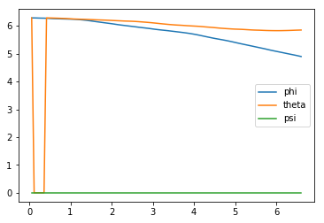

```python
plt.plot(results['time'], results['phi'], label='phi')
plt.plot(results['time'], results['theta'], label='theta')
plt.plot(results['time'], results['psi'], label='psi')
plt.legend()
_ = plt.ylim()
```

before plotting the velocities (in radians per second) corresponding to each of the Euler angles.

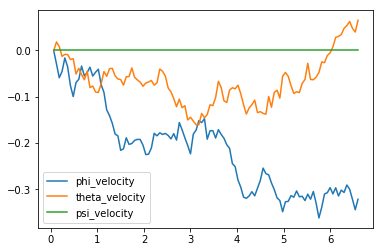

```python
plt.plot(results['time'], results['phi_velocity'], label='phi_velocity')
plt.plot(results['time'], results['theta_velocity'], label='theta_velocity')
plt.plot(results['time'], results['psi_velocity'], label='psi_velocity')
plt.legend()
_ = plt.ylim()
```

Finally, you can use the code cell below to print the agent's choice of actions.

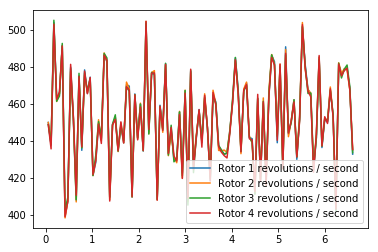

```python
plt.plot(results['time'], results['rotor_speed1'], label='Rotor 1 revolutions / second')
plt.plot(results['time'], results['rotor_speed2'], label='Rotor 2 revolutions / second')
plt.plot(results['time'], results['rotor_speed3'], label='Rotor 3 revolutions / second')
plt.plot(results['time'], results['rotor_speed4'], label='Rotor 4 revolutions / second')
plt.legend()
_ = plt.ylim()
```

When specifying a task, you will derive the environment state from the simulator. Run the code cell below to print the values of the following variables at the end of the simulation:

- `task.sim.pose` (the position of the quadcopter in ($x,y,z$) dimensions and the Euler angles),
- `task.sim.v` (the velocity of the quadcopter in ($x,y,z$) dimensions), and
- `task.sim.angular_v` (radians/second for each of the three Euler angles).

```python
# the pose, velocity, and angular velocity of the quadcopter at the end of the episode
print(task.sim.pose)
print(task.sim.v)
print(task.sim.angular_v)
```

```
[ 32.78776882 -44.86383222   0.           4.8968056    5.84826635
   0.        ]
[  7.69155661 -23.74003445 -35.25942459]
[-0.32132802  0.06525505  0.        ]
```

Let's have a look at the actual 3D trajectory:

```python
# Idea from:
#   https://stackoverflow.com/questions/36721861/matplotlib-plot-movements-in-3d
#   https://matplotlib.org/mpl_toolkits/mplot3d/tutorial.html#mplot3d-tutorial

from mpl_toolkits.mplot3d import Axes3D

def plot_trajectory(results, target=None):
    fig = plt.figure(figsize=(10, 10))
    ax = fig.gca(projection='3d')

    ax.scatter(results['x'][0],
               results['y'][0],
               results['z'][0],
               s=100,
               c='green',
               label='Start point')

    ax.plot(results['x'], results['y'], [0] * len(results['z']), c='grey')
    ax.plot([0] * len(results['x']), results['y'], results['z'], c='grey')
    ax.plot(results['x'], [0] * len(results['y']), results['z'], c='grey')

    ax.plot(results['x'], results['y'], results['z'])

    if target is not None:
        ax.scatter(target[0],
                   target[1],
                   target[2],
                   s=100,
                   c='blue',
                   label='Target point')

    ax.scatter(results['x'][-1],
               results['y'][-1],
               results['z'][-1],
               s=100,
               c='red',
               label='End point')

    ax.set_xlabel('X')
    ax.set_ylabel('Y')
    ax.set_zlabel('Z')
    ax.legend()

    ax.view_init(elev=15)

    plt.show()
```

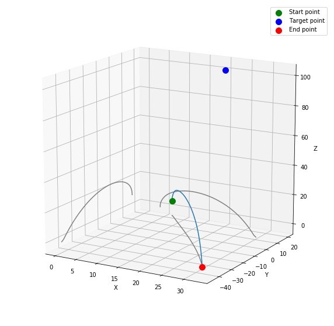

```python
plot_trajectory(results, target_pos)
```

Some useful functions for plotting results:

```python
def plot_evolution(results):
    fig = plt.figure(figsize=(8, 5))
    ax = fig.add_subplot(111)
    ax.plot(results['time'], results['x'], label='x')
    ax.plot(results['time'], results['y'], label='y')
    ax.plot(results['time'], results['z'], label='z')
    ax.legend()

    plt.show()

def plot_velocity(results):
    fig = plt.figure(figsize=(8, 5))
    ax = fig.add_subplot(111)
    ax.plot(results['time'], results['x_velocity'], label='x_hat')
    ax.plot(results['time'], results['y_velocity'], label='y_hat')
    ax.plot(results['time'], results['z_velocity'], label='z_hat')
    ax.legend()

    plt.show()

def plot_euler_angles(results):
    fig = plt.figure(figsize=(8, 5))
    ax = fig.add_subplot(111)
    ax.plot(results['time'], results['phi'], label='phi')
    ax.plot(results['time'], results['theta'], label='theta')
    ax.plot(results['time'], results['psi'], label='psi')
    ax.legend()

    plt.show()

def plot_choice_of_actions(results):
    fig = plt.figure(figsize=(8, 5))
    ax = fig.add_subplot(111)
    ax.plot(results['time'], results['rotor_speed1'], label='Rotor 1 revolutions / second')
    ax.plot(results['time'], results['rotor_speed2'], label='Rotor 2 revolutions / second')
    ax.plot(results['time'], results['rotor_speed3'], label='Rotor 3 revolutions / second')
    ax.plot(results['time'], results['rotor_speed4'], label='Rotor 4 revolutions / second')
    ax.legend()

    plt.show()

def plot_rewards(results):
    fig = plt.figure(figsize=(8, 5))
    ax = fig.add_subplot(111)
    ax.plot(results['time'], results['reward'], label='reward')
    ax.legend()

    plt.show()

def print_last_sim_state(task):
    print('Pose', task.sim.pose)
    print('Velocity', task.sim.v)
    print('Angles', task.sim.angular_v)

def moving_average (values, window):
    weights = np.repeat(1.0, window)/window
    sma = np.convolve(values, weights, 'valid')
    return sma

def plot_total_rewards(rewards):
    fig = plt.figure(figsize=(12, 5))
    ax = fig.add_subplot(111)
    ax.plot(rewards, label='total rewards')

    sma = moving_average(rewards, 10)
    ax.plot(sma, label='sma')
    ax.legend()

    plt.show()
```

#### Training function

```python
def train(agent, task, num_episodes):
    total_rewards = []
    best_total_reward = -np.inf
    best_episode = []

    rollback_threshold = 30
    rollback_counter = rollback_threshold

    for i_episode in range(1, num_episodes+1):
        state = agent.reset_episode() # start a new episode
        steps = 0
        episode_reports = []

        while True:
            action = agent.act(state)
            next_state, reward, done = task.step(action)
            agent.step(action, reward, next_state, done)
            state = next_state
            steps += 1

            report = [task.sim.time] + \
                list(task.sim.pose) + \
                list(task.sim.v) + \
                list(task.sim.angular_v) + \
                list(action) + \
                [reward]

            episode_reports.append(report)

            if done:
                total_rewards.append(agent.total_reward)

                if agent.total_reward > best_total_reward:
                    best_total_reward = agent.total_reward
                    best_reports = episode_reports
                    agent.current_weights_best()
#                     rollback_counter = rollback_threshold
#                 else:
#                     rollback_counter -= 1
#                     if rollback_counter == 0:
#                         agent.set_best_weights()
#                         rollback_counter = rollback_threshold

                # [debug]

                print("\rEpisode = {}, steps = {}, score = {:.3f} (best = {:.3f}), total reward = {:.3f} (best = {:.3f})".format(
                    i_episode,
                    steps,
                    agent.score,
                    agent.best_score,
                    agent.total_reward,
                    best_total_reward), end="")

                with open('best_reports_train.csv', 'w') as csvfile:
                    writer = csv.writer(csvfile)
                    writer.writerow(labels)
                    for report in best_reports:
                        writer.writerow(report)

                break

        sys.stdout.flush()

        # We finish training if reached a decent distance from the target
        if abs(task.sim.pose[:3] - task.target_pos).sum() < 10:
            break

    return total_rewards
```

In the sample task in `task.py`, we use the 6-dimensional pose of the quadcopter to construct the state of the environment at each timestep. However, when amending the task for your purposes, you are welcome to expand the size of the state vector by including the velocity information. You can use any combination of the pose, velocity, and angular velocity - feel free to tinker here, and construct the state to suit your task.

## The Task

A sample task has been provided for you in `task.py`. Open this file in a new window now.

The `__init__()` method is used to initialize several variables that are needed to specify the task.

- The simulator is initialized as an instance of the `PhysicsSim` class (from `physics_sim.py`).
- Inspired by the methodology in the original DDPG paper, we make use of action repeats. For each timestep of the agent, we step the simulation `action_repeats` timesteps. If you are not familiar with action repeats, please read the **Results** section in [the DDPG paper](https://arxiv.org/abs/1509.02971).
- We set the number of elements in the state vector. For the sample task, we only work with the 6-dimensional pose information. To set the size of the state (`state_size`), we must take action repeats into account.
- The environment will always have a 4-dimensional action space, with one entry for each rotor (`action_size=4`). You can set the minimum (`action_low`) and maximum (`action_high`) values of each entry here.
- The sample task in this provided file is for the agent to reach a target position. We specify that target position as a variable.

The `reset()` method resets the simulator. The agent should call this method every time the episode ends. You can see an example of this in the code cell below.

The `step()` method is perhaps the most important. It accepts the agent's choice of action `rotor_speeds`, which is used to prepare the next state to pass on to the agent. Then, the reward is computed from `get_reward()`. The episode is considered done if the time limit has been exceeded, or the quadcopter has travelled outside of the bounds of the simulation.

In the next section, you will learn how to test the performance of an agent on this task.

## The Agent

The sample agent given in `agents/policy_search.py` uses a very simplistic linear policy to directly compute the action vector as a dot product of the state vector and a matrix of weights. Then, it randomly perturbs the parameters by adding some Gaussian noise, to produce a different policy. Based on the average reward obtained in each episode (`score`), it keeps track of the best set of parameters found so far, how the score is changing, and accordingly tweaks a scaling factor to widen or tighten the noise.

Run the code cell below to see how the agent performs on the sample task.

```python
import sys
import pandas as pd
```

```python
from agents.policy_search import PolicySearch_Agent
from task import Task

runtime = 1000
num_episodes = 1000

task = Task(init_pose, init_velocities, init_angle_velocities, runtime, target_pos)
agent = PolicySearch_Agent(task)

total_rewards = train(agent, task, num_episodes)
```

[output not shown]

Ploting total rewards and moving avarage:

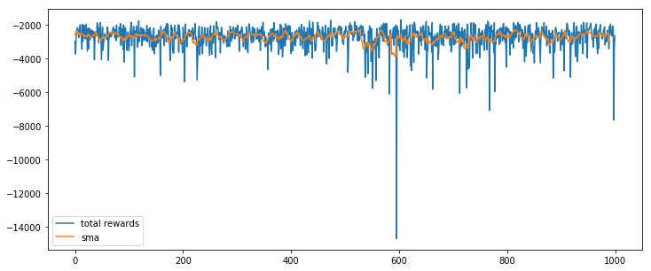

```python
plot_total_rewards(total_rewards)
```

This agent should perform very poorly on this task. And that's where you come in!

Let's give it a try and run the simulation plotting the trajectory of the best result

```python
def run_simulation(agent, task, file_output = 'data.csv'):
    results = {x : [] for x in labels}
    results['reward'] = []

    state = agent.reset_episode()

    with open(file_output, 'w') as csvfile:
        writer = csv.writer(csvfile)
        writer.writerow(labels)

        while True:
            rotor_speeds = agent.act(state)
            next_state, reward, done = task.step(rotor_speeds)
            agent.step(rotor_speeds, reward, next_state, done)
            state = next_state

            report = [task.sim.time] + \
                list(task.sim.pose) + \
                list(task.sim.v) + \
                list(task.sim.angular_v) + \
                list(rotor_speeds) + \
                [reward]

            for ii in range(len(labels)):
                results[labels[ii]].append(report[ii])

            writer.writerow(report)

            if done:
                break

    return results
```

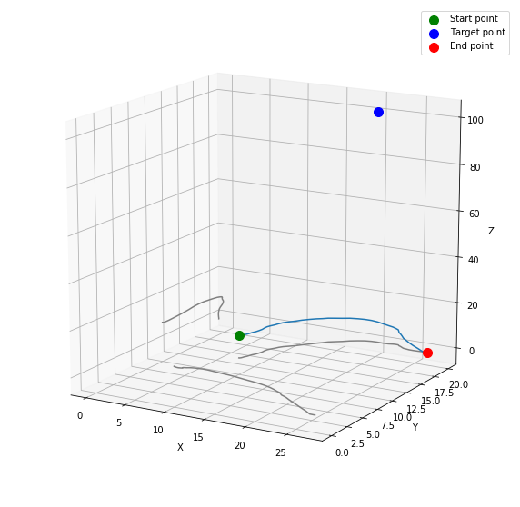

```python
agent.w = agent.best_w
results = run_simulation(agent, task, 'policy_search.csv')
plot_trajectory(results, target_pos)
```

#### Evolution of position:

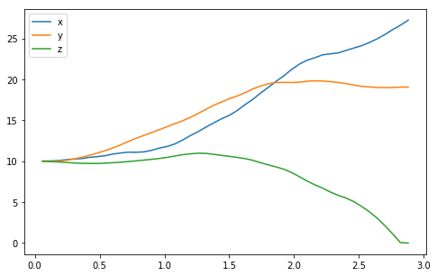

```python
plot_evolution(results)
```

#### Velocity:

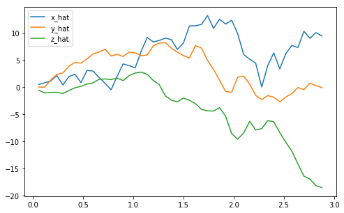

```python
plot_velocity(results)
```

#### Euler angles:

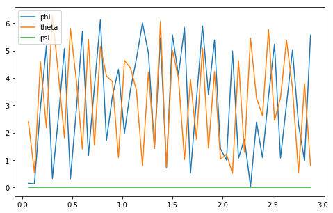

```python
plot_euler_angles(results)
```

#### Agent's choice of actions

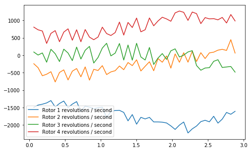

```python
plot_choice_of_actions(results)
```

Animation using Quadrotor class from https://github.com/AtsushiSakai/PythonRobotics

```python
from quadrotor import Quadrotor
```

```
Timesteps: 48
```

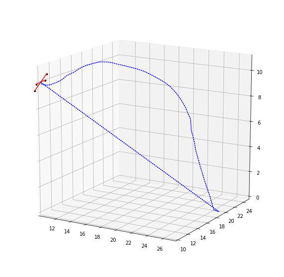

```python
print('Timesteps:', len(results['time']))

q = Quadrotor(results, target=target_pos, size=2)
```

```python
from IPython.display import HTML

def to_html5_str(anim_file_name):
    return '<video controls><source src="{}.mp4" type="video/mp4"></video>'.format(anim_file_name)

# HTML(to_html5_str(q.anim_file_name))
```

[figure not shown]

## Define the Task, Design the Agent, and Train Your Agent!

Amend `task.py` to specify a task of your choosing. If you're unsure what kind of task to specify, you may like to teach your quadcopter to takeoff, hover in place, land softly, or reach a target pose.

After specifying your task, use the sample agent in `agents/policy_search.py` as a template to define your own agent in `agents/agent.py`. You can borrow whatever you need from the sample agent, including ideas on how you might modularize your code (using helper methods like `act()`, `learn()`, `reset_episode()`, etc.).

Note that it is **highly unlikely** that the first agent and task that you specify will learn well. You will likely have to tweak various hyperparameters and the reward function for your task until you arrive at reasonably good behavior.

As you develop your agent, it's important to keep an eye on how it's performing. Use the code above as inspiration to build in a mechanism to log/save the total rewards obtained in each episode to file. If the episode rewards are gradually increasing, this is an indication that your agent is learning.

## Task and Agent files:

- tasks/task_takeoff.py
- agents/policy_search.py
- agents/DDPG/agent.py
- agents/DDPG/actor_critic.py
- agents/DDPG/memory.py
- agents/DDPG/noise.py

```python
from agents.agent import DDPG_Agent
from tasks.task_takeoff import Task_TakeOff

runtime = 1000 # We give it enough time for the agent to act
num_episodes = 1000

task = Task_TakeOff(init_pose, init_velocities, init_angle_velocities, runtime, target_pos)

print('Instantiazing agent...')
agent = DDPG_Agent(task)
print('Ready to train!!')
```

```
Instantiazing agent...
Ready to train!!
```

```python
total_rewards = train(agent, task, num_episodes)
```

[output not shown]

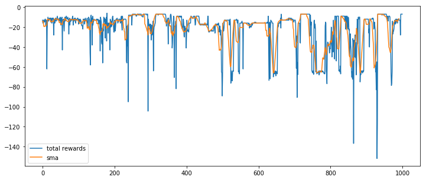

```python
plot_total_rewards(total_rewards)
```

Doesn't look like there is much learning here though. Let's see how the best episode performs

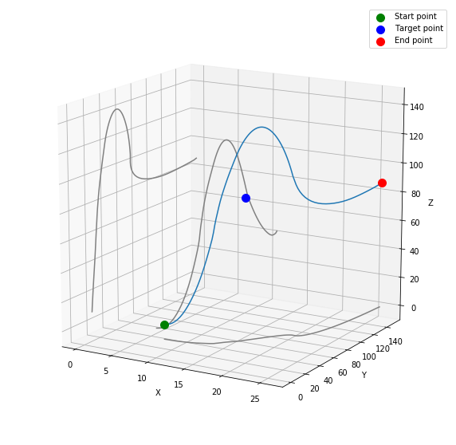

```python
agent.set_training(False)
results = run_simulation(agent, task, 'ddpg_agent.csv')
plot_trajectory(results, target_pos)
```

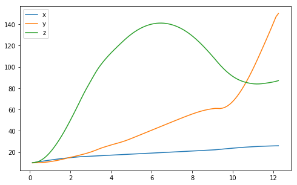

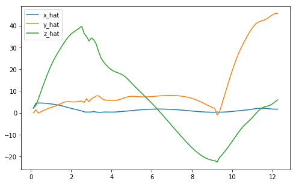

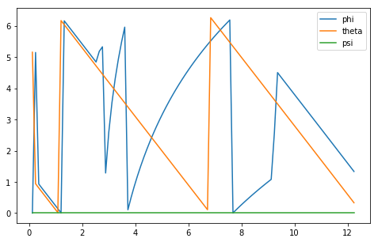

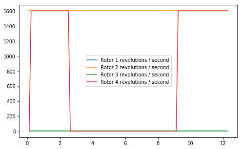

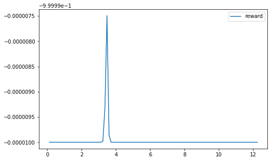

```
Pose [ 26.0540801  150.          87.09663132   1.33315674   0.33108524
   0.        ]
Velocity [ 1.68197132 45.61719351  5.90564648]
Angles [51.25985506 51.25985506  0.        ]
```

```python
plot_evolution(results)
plot_velocity(results)
plot_euler_angles(results)
plot_choice_of_actions(results)
plot_rewards(results)
print_last_sim_state(task)
```

```
Timesteps: 102
```

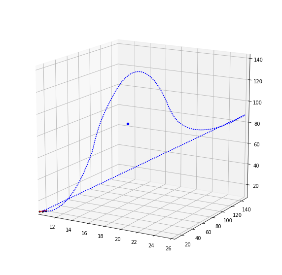

```python
print('Timesteps:', len(results['time']))
q = Quadrotor(results, target=target_pos, size=2)
```

```python
# HTML(to_html5_str(q))
```

[figure not shown]

Wow!! it actually tries its best to stay close to the target. You can see that by the way it tries to correct the altitude. After surpasing the target it goes down and up again. Unfortunately it moves away horizontally until it reaches one boundary finishing the episode

```python
#Let's save these weights
agent.actor_local.model.save_weights('actor_local.best_weights.hdf5')
agent.actor_target.model.save_weights('actor_target.best_weights.hdf5')
agent.critic_local.model.save_weights('critic_local.best_weights.hdf5')
agent.critic_target.model.save_weights('critic_target.best_weights.hdf5')
```

#### Noise parameters

```python
print('Mu:', agent.exploration_mu)
print('Theta:', agent.exploration_theta)
print('Sigma:', agent.exploration_sigma)
```

```
Mu: 0
Theta: 0.03
Sigma: 0.09
```

#### Memory parameters

```python
print('Buffer size:', agent.buffer_size)
print('Batch size:', agent.batch_size)
```

```
Buffer size: 100000
Batch size: 64
```

#### Algorithm parameters

```python
print('Discount factor:', agent.gamma)
print('Soft update Tau:', agent.tau)
```

```
Discount factor: 0.99
Soft update Tau: 0.1
```

#### Task parameters

```python
print('Action repeat:', task.action_repeat)
print('State size:', task.state_size)
print('Action low:', task.action_low)
print('Action high:', task.action_high)
print('Action size:', task.action_size)
```

```
Action repeat: 6
State size: 72
Action low: 0
Action high: 1600
Action size: 4
```

## Plot the Rewards

Once you are satisfied with your performance, plot the episode rewards, either from a single run, or averaged over multiple runs.

Note: this was before the first review. Keeping it for comparison reasons

#### Rewards during training

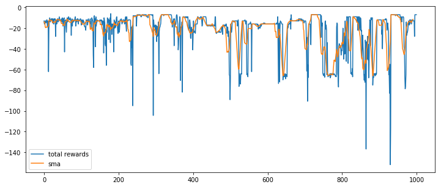

```python
plot_total_rewards(total_rewards)
```

#### Rewards best episode

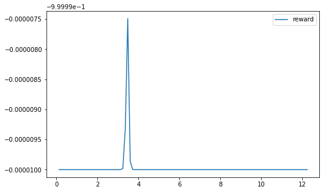

```python
plot_rewards(results)
```

## Reflections

**Question 1**: Describe the task that you specified in `task.py`. How did you design the reward function?

**Answer**:

I took as template the task already provided and played around with different settings. The plan was to make the quadcopter take off, reach the target and stay there. In order to do so I made the following changes (see task_takeoff.py):

1. I increased the action repeats up to 6. This definitely sped up the training. I seem to have also gotten always better results, probably because the agent had more observations.
2. I also increased the number of states up to 12 (pose, velocities and angular_velocities), giving the agent more information to learn from.
3. I increased the action high up to 1600rpm so the quadcopter could correct position fast.

**Design of the reward function**: This is the part where I spent, literally, tons of hours. Quite frustraiting since I could hardly get decent results. After lots of training, trial and error, I came up with this function which got me the best results. It has four main components:

1. Reward proporcional to its vertical velocity up to 1, encouraging the quadcopter to take off and go up slowly: `reward = min(self.sim.v[2], 1)`
2. Penalty for changing angles too fast: `reward -= .002 * abs(self.sim.angular_v).sum()**2`
3. Penalty for moving away from the target: `reward -= .03 * abs(self.sim.pose[:3] - self.target_pos).sum()**2`
4. Finally I'm scaling the reward down to [-1, 1] range using `np.tanh`, avoiding instability in training due to exploding gradients and improving performance of the deep neural network models (actor and critic), and dividing it by `action_repeats`, since the reward function will be called `action_repeats` times per action: `return np.tanh(reward) / self.action_repeat`

**Question 2**: Discuss your agent briefly, using the following questions as a guide:

- What learning algorithm(s) did you try? What worked best for you?
- What was your final choice of hyperparameters (such as $\alpha$, $\gamma$, $\epsilon$, etc.)?
- What neural network architecture did you use (if any)? Specify layers, sizes, activation functions, etc.

**Answer**:

1. I did lots research where I stumbled upon different RL Actor-Critic, model-free and off-policy algorithms to try, such as A2C and A3C algorithms, as well as the proposed one, DDPG (see agent.py), which is the one presented in the paper [Continuous control with deep reinforcement learning](https://arxiv.org/pdf/1509.02971.pdf) and also perfect for this problem with continous action spaces.
2. This part was also a tricky one to get right, and still I'm quite sure there is room for improvement, but I believe I achieved an optimal enough hyperparameters tunning.

   ```
    a. Noise parameters. I decreased both, Theta and Sigma reducing the noise and how much consecutive actions vary from one to another:
        1. Mu: 0
        2. Theta: 0.03
        3. Sigma: 0.09

    b. Memory parameters stay the same (suggested ones):
        1. Buffer size: 100000
        2. Batch size: 64

    c. Others algorithm parameters. I increased Tau for more agressive target weights update:
        1. Discount factor: 0.99
        2. Soft update Tau: 0.1
   ```

3. Network architecture used (see actor_critic.py):

   ```
    a. Actor: Three layers with 256, 128, 64 units respectively, with batch normalization between the linear and non-linear layers to increase stability, a litle bit of regularization effect and speed up training. Using ReLU as activation function. Same architecture for local and target models.

    b. Critic: Similar architecture as the one use for the Actor model, for both states and actions
   ```

**Question 3**: Using the episode rewards plot, discuss how the agent learned over time.

- Was it an easy task to learn or hard?
- Was there a gradual learning curve, or an aha moment?
- How good was the final performance of the agent? (e.g. mean rewards over the last 10 episodes)

**Question 4**: Briefly summarize your experience working on this project. You can use the following prompts for ideas.

- What was the hardest part of the project? (e.g. getting started, plotting, specifying the task, etc.)
- Did you find anything interesting in how the quadcopter or your agent behaved?

**Answer**: Overall the experience and knowlage gained while working on this project has been excellent. I learned more by doing research and trying than with what's provided in the theory, which in my opinion is only scratching the surface of Reinforcement Learning. Great overview though, and well explained, but to be able to understand and complete this project, it's definitely not enough. Although I'm guessing that's also the purpose of it, doing research, trial and error. It's the only way to fully understand something.

1. The hardest part of this project was getting started. I had to go through the theory over and over again to have a better grasp of the concepts and ideas behind these algorithms. Then trying to understand each single line of code provided, since there was only an overview of how Actor Critic algorithms work, it was hard for me to understand 100% the whole DDPG implementation. Second hardest thing was coming up with a good enough reward function. I tried thoudsands of possibilities there. Trying to always make sense with the components (rewards, penalties, bonuses) used to compose this function. At some point I got quite frustrated because I didn't see improvement, and the amount of hyperparameters to tune didn't make it easier... On the other hand, plotting was quite simple, and thanks to the project PythonRobotics I found the way to animate the trajectory of the quadcopter, giving me a better idea of how my agent was performing.
2. At the beginning my quadcopter was always falling down. Initial position was always higher than the lower boundary in the z axis (that's where I wanted it to start). It was only when I started messing with the velocities, penalizing for negative velocity in the z axis, when it began going up. Once I managed to make it take off, I had to work on stopping it because it was overshooting all the way up, straight line to the upper boundary (I was also penalizing for moving horizontally). A big improvement came when I decided to mess with the parameters of Ornstein–Uhlenbeck Noise. By reducing Theta and Sigma, I managed to get a more stable and less crazy quadcopter.

# Second attempt

After the first review, I was failing at showing a clear learning by my agent. Let's play around a bit more with the hyperparameters and see if my agent makes some progress:

```python
from agents.agent import DDPG_Agent
from tasks.task_takeoff import Task_TakeOff

runtime = 50
num_episodes = 5000

task = Task_TakeOff(init_pose, init_velocities, init_angle_velocities, runtime, target_pos)

print('Instantiazing agent...')
agent = DDPG_Agent(task)
print('Ready to train!!')
```

```
Instantiazing agent...
Ready to train!!
```

```python
total_rewards = train(agent, task, num_episodes)
```

```
Episode = 5000, steps = 21, score = -0.945 (best = 1.024), total reward = -19.852 (best = 261.714)
```

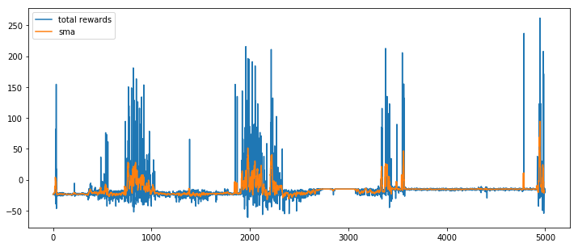

```python
plot_total_rewards(total_rewards)
```

```
Instantiazing agent...
Ready to train!!


Saving best weights for total reward -16.700 in 17 steps
Episode = 1, steps = 17, score = 0.000 (best = -inf), total reward = -16.700 (best = -16.700)

Saving best weights for total reward -16.699 in 17 steps
Episode = 2, steps = 17, score = 0.000 (best = -inf), total reward = -16.699 (best = -16.699)

Saving best weights for total reward -16.699 in 17 steps
Episode = 5, steps = 20, score = -0.982 (best = -0.669), total reward = -19.644 (best = -16.699)

Saving best weights for total reward -14.499 in 16 steps
Episode = 18, steps = 22, score = -0.998 (best = -0.463), total reward = -21.947 (best = -14.499)

Saving best weights for total reward -13.657 in 14 steps
Episode = 19, steps = 14, score = -0.975 (best = -0.463), total reward = -13.657 (best = -13.657)

Saving best weights for total reward 32.314 in 24 steps
Episode = 20, steps = 24, score = 1.346 (best = 1.346), total reward = 32.314 (best = 32.314)

Saving best weights for total reward 32.337 in 24 steps
Episode = 21, steps = 24, score = 1.347 (best = 1.347), total reward = 32.337 (best = 32.337)

Saving best weights for total reward 32.339 in 24 steps
Episode = 29, steps = 24, score = 1.347 (best = 1.347), total reward = 32.339 (best = 32.339)

Saving best weights for total reward 33.339 in 25 steps
Episode = 276, steps = 36, score = -0.548 (best = 1.347), total reward = -19.721 (best = 33.339)

Saving best weights for total reward 45.103 in 38 steps
Episode = 392, steps = 27, score = 1.230 (best = 1.347), total reward = 33.221 (best = 45.103)
```

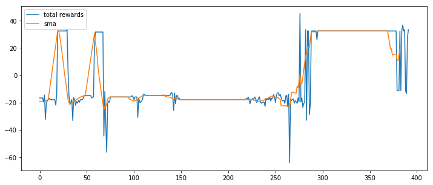

```python
from agents.agent import DDPG_Agent
from tasks.task_takeoff import Task_TakeOff

runtime = 50
num_episodes = 1000

init_pose = np.array([10., 10., 10., 0., 0., 0.])
target_pos = np.array([20., 20., 30.])

task = Task_TakeOff(init_pose, init_velocities, init_angle_velocities, runtime, target_pos)

print('Instantiazing agent...')
agent = DDPG_Agent(task)
print('Ready to train!!')

total_rewards = train(agent, task, num_episodes)
plot_total_rewards(total_rewards)
```

Take a look at best_reports_train.csv to see the actions the agent took to reach the target in its best moment, as well as the position velocities and rewards per time step of the quadcopter

As we can see, there is finally some learning. Changes I made compared to the first attempt:

#### Noise parameters

```python
print('Mu:', agent.exploration_mu)
print('Theta:', agent.exploration_theta)
print('Sigma:', agent.exploration_sigma)
```

```
Mu: 0
Theta: 0.01
Sigma: 0.01
```

#### Memory parameters

```python
print('Buffer size:', agent.buffer_size)
print('Batch size:', agent.batch_size)
```

```
Buffer size: 1000000
Batch size: 64
```

#### Algorithm parameters

```python
print('Discount factor:', agent.gamma)
print('Soft update Tau:', agent.tau)
```

```
Discount factor: 0.99
Soft update Tau: 1e-05
```

#### Task parameters

```python
print('Action repeat:', task.action_repeat)
print('State size:', task.state_size)
print('Action low:', task.action_low)
print('Action high:', task.action_high)
print('Action size:', task.action_size)
```

```
Action repeat: 4
State size: 36
Action low: 0
Action high: 1200
Action size: 4
```

#### Network architecture

- **Actor**: Three layers with 32, 64, 32 units respectively, with batch normalization between the linear and non-linear. Using ReLU as activation function. I also added a GaussianNoise layer to add parameter noise following this interesting article https://openai.com/blog/better-exploration-with-parameter-noise/ to improve exploration. Adam optimizer with learning rate = 0.001
- **Critic**: Two layers for both state and actions with 32, 64 units with kernel regularizer l2 = 1e-4, with batch normalization between the linear and non-linear layers, and dropout layer rate = 0.2. Adam optimizer with learning rate = 1e-4. I'm trying to follow a suggestion from one of the mentors to make the Critic learn slower: https://study-hall.udacity.com/rooms/community:nd009t:628258-project-347/community:thread-10129448698-712819

#### Reward function

see task_takeoff.py:

```python
class Task_TakeOff():
    ...

    def get_reward(self):
        # Reward proportional to its vertical velocity up to 10
        # encouraging the quadcopter to take off and go up
        reward = min(self.sim.v[2], 10)

        # Penalty for moving away from the target
        reward -= .001 * abs(self.sim.pose[:3] - self.target_pos).sum()**2

        return np.tanh(reward) / self.action_repeat

    def step(self, rotor_speeds):
        reward = 0
        state_all = []

        for _ in range(self.action_repeat):
            done = self.sim.next_timestep(rotor_speeds)
            reward += self.get_reward()
            state_all.append(list(self.sim.pose) + list(self.sim.v))

        if self.sim.pose[2] > self.target_pos[2]:
            # Bonus for reaching the target's height
            reward += 10

            # And we're done
            done = True

        next_state = np.concatenate(state_all)

        return next_state, reward, done
```

I'm stopping the episode when the agent reaches the target's height, giving the agent a generous bonus. With this we acknowledge that it succeeded

#### Training function

see Training function:

```python
def train(agent, task, num_episodes):
    ...
        # We finish training if reached a decent distance from the target
        if abs(task.sim.pose[:3] - task.target_pos).sum() < 10:
            break
    ...
```

I decided to stop the training if the agent has learnt a good policy that makes it reach the target's surroundings.